# Data Analysis 3: Multivariate Analysis and Factor Analysis

SKPM20: Quantitative Methods 2026

nils.holmberg@iko.lu.se

## Course literature

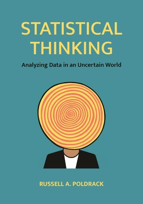

Poldrack (2023)

[figure not shown]

Field (2022)

[figure not shown]

Van de Ven (2007)

## Open science methods

- **Replicability**: Python enables reproducible research with shareable scripts.
- **Transparency**: Open-source code makes analyses fully visible.
- **Collaboration**: Supports teamwork via GitHub and Jupyter Notebooks.
- **Open Source**: Free and community-driven for open science. 🚀

[figure not shown]

## AI use in academic work

- OK: brainstorm ideas, do research
- OK: generate project materials
- OK: data analysis, statistics tools
- Not OK: copy-paste text to your exam
- Not OK: generate fake empirical data
- Not OK: upload content you dont own
- Not OK: upload data with personal info
- https://gemini.google.com/

## Lecture overview

- `Recap, computer lab 2`
- Bivariate analysis
- Hypothesis testing
- `Multivariate analysis`
- Simple linear regression
- Multiple regression
- Model diagnostics
- `Factor analysis`
- Heatmaps
- Factor count
- Factor loadings
- `Intro, computer lab 3`
- Model specification
- Interpretation, diagnostics

Recap,  
Computer Lab 2

## Penguins dataset

- `species` (nominal)
- `island` (nominal)
- `bill_length_mm` (cont.)
- `bill_depth_mm` (cont.)
- `flipper_length_mm` (cont.)
- `body_mass_g` (cont.)
- `sex` (binary)

```python
import pandas as pd

# Load the dataset
path = "../../csv/penguins.tsv"
dfp = pd.read_csv(path, sep="\t")

print(dfp["species"].value_counts(dropna=False))
```

```
species
Adelie       152
Gentoo       124
Chinstrap     68
Name: count, dtype: int64
```

## Theoretical model

- Download sample [dataset](https://github.com/cca-cce/osm-comm/raw/refs/heads/main/csv/penguins.tsv) and analyze model
- Perform descriptive statistics and data transformations
- `Perform bivariate analyses and hypothesis testing`
- Perform multivariate analysis, multiple regression

```
graph LR
    direction LR

    subgraph Analysis [<b>Effects on penguin body mass</b>]
        direction LR

        %% Independent Variables
        iv1(bill_length_mm)
        iv2(species)
        iv3(sex)

        %% Dependent Variable
        dv1[[<b>body_mass_g</b>]]

        %% Connections
        iv1 --> dv1
        iv2 --> dv1
        iv3 --> dv1
    end

    %% Node Styling
    style Analysis fill:#f9f9f9,stroke:#ccc,stroke-dasharray: 5 5
    style iv1 fill:#ffffff,stroke:#333,color:#000
    style iv2 fill:#ffffff,stroke:#333,color:#000
    style iv3 fill:#ffffff,stroke:#333,color:#000
    style dv1 fill:#ff8401,stroke:#2b4156,color:#fff

    %% Darker Arrow Styling (Indices start at 0)
    linkStyle 0,1,2 stroke:#000,stroke-width:2px;
```

## Bill Length and Body Mass

- Model treats `bill_length_mm` as a continuous predictor of `body_mass_g`
- Each point is one penguin with complete values on both variables
- Scatterplot checks direction, form, and strength of association
- Trend line summarizes the average linear relationship

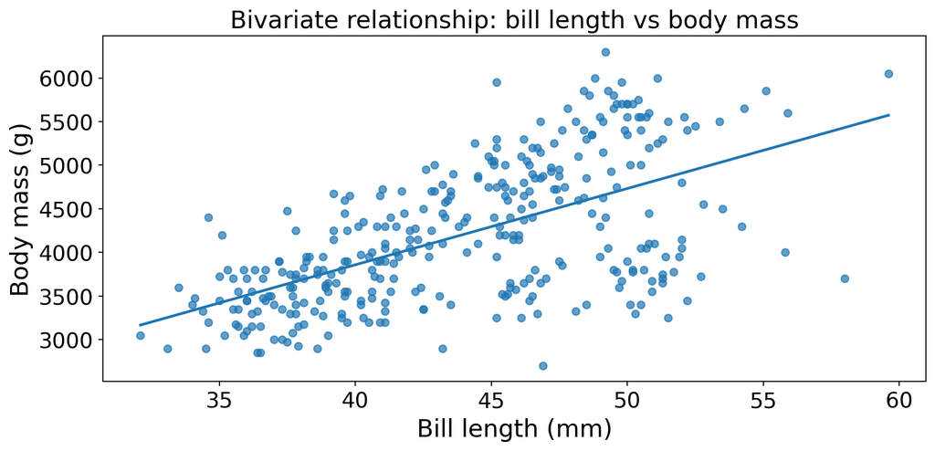

## Testing Bill Length Association

- Null hypothesis: no linear association between bill length and body mass
- Test statistic is Pearson’s correlation coefficient `r`
- P-value quantifies how extreme the observed `r` is under the null
- One direct `pearsonr` call returns both `r` and the p-value
- Small p-values indicate evidence against zero linear correlation

```python
import pandas as pd
from scipy import stats

# Load and clean in one step
df = pd.read_csv("../../csv/penguins.tsv", sep="\t").dropna(
    subset=["bill_length_mm", "body_mass_g"]
)

# One-liner for correlation and p-value
r, p = stats.pearsonr(df["bill_length_mm"], df["body_mass_g"])

print(f"Correlation (r): {r:.3f}")
print(f"P-value: {p:.3g}")
```

```
Correlation (r): 0.595
P-value: 3.81e-34
```

## Species and Body Mass

- Model treats `species` as a categorical predictor of body mass
- Grouped distributions reveal between-species differences in means/spread
- Overlap across boxes helps assess likely effect size
- This is a one-factor design with three species levels

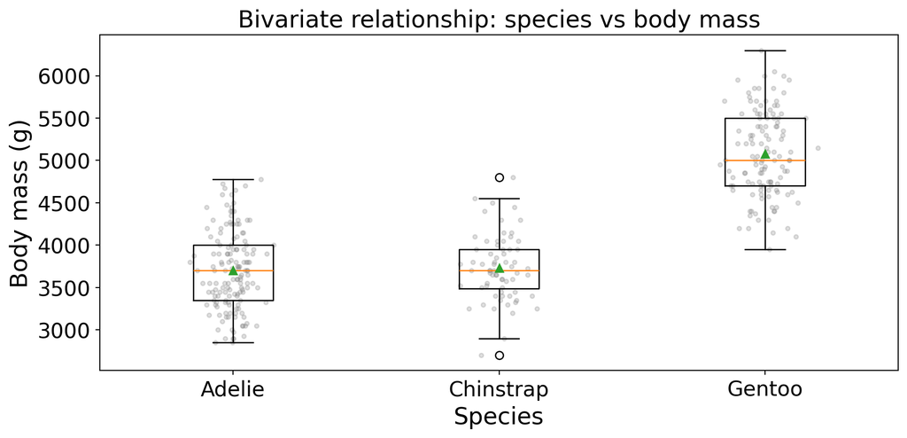

## Testing Species Differences

- Null hypothesis: all species have the same population mean body mass
- Appropriate parametric test is one-way ANOVA
- ANOVA compares between-group variation to within-group variation
- Eta squared quantifies how much variance species explains

```python
import pandas as pd
from scipy import stats

df = pd.read_csv("../../csv/penguins.tsv", sep="\t").dropna(subset=["species", "body_mass_g"])
groups = [g.to_numpy() for _, g in df.groupby("species")["body_mass_g"]]

f_stat, p = stats.f_oneway(*groups)

# Effect size: eta squared
grand_mean = df["body_mass_g"].mean()
ss_between = sum(len(g) * (g.mean() - grand_mean) ** 2 for g in groups)
ss_total = ((df["body_mass_g"] - grand_mean) ** 2).sum()
eta_squared = ss_between / ss_total

print(f"ANOVA F-statistic: {f_stat:.3f}")
print(f"P-value: {p:.3g}")
print(f"Eta squared: {eta_squared:.3f}")
```

```
ANOVA F-statistic: 343.626
P-value: 2.89e-82
Eta squared: 0.670
```

## Sex and Body Mass

- Model treats `sex` as a binary categorical predictor of body mass
- Missing or unknown sex values are excluded for this bivariate view
- Group distributions show central tendency and heterogeneity
- Differences can be visualized before formal testing

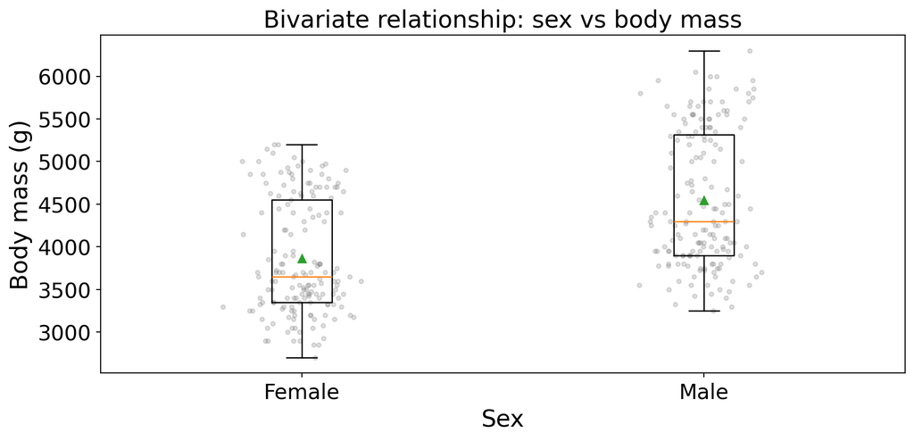

## Testing Sex Mean Difference

- Null hypothesis: mean body mass is equal for female and male penguins
- Appropriate test is Welch’s two-sample t-test
- Welch test is robust to unequal variances across groups
- Mean difference helps interpret effect direction and magnitude

```python
import pandas as pd
from scipy import stats

df = pd.read_csv("../../csv/penguins.tsv", sep="\t").dropna(subset=["sex", "body_mass_g"])
d = df[["sex", "body_mass_g"]]
d = d[d["sex"].isin(["Female", "Male"])]

female = d.loc[d["sex"] == "Female", "body_mass_g"].to_numpy()
male = d.loc[d["sex"] == "Male", "body_mass_g"].to_numpy()
t_stat, p = stats.ttest_ind(male, female, equal_var=False)
mean_diff = male.mean() - female.mean()

print(f"Welch t-statistic: {t_stat:.3f}")
print(f"P-value: {p:.3g}")
print(f"Mean difference (Male - Female): {mean_diff:.1f} g")
```

```
Welch t-statistic: 8.555
P-value: 4.79e-16
Mean difference (Male - Female): 683.4 g
```

Simple Linear Regression

## Gentoo Sample and Regression Line

- Use 10 random Gentoo penguins
- Outcome is body mass
- Predictor is bill length
- Fit a straight line to the sample
- Slope shows expected mass change per mm

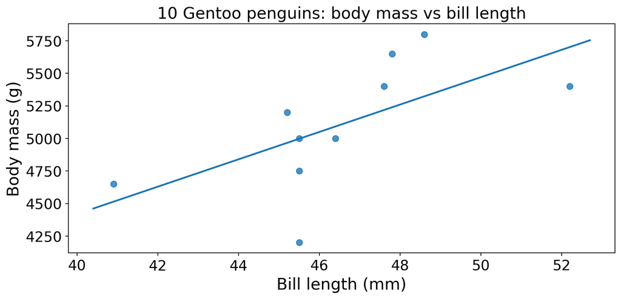

## Slope Means Change in Y per Unit X

- Slope is rise over run
- Here run is plus 1 mm bill length
- Rise is the model change in body mass
- Positive slope means y increases as x increases
- Slope units are grams per millimeter

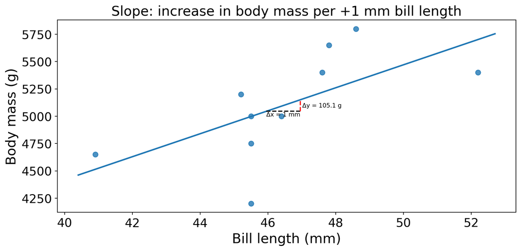

## Least Squares Residuals for All Points

- Residual equals observed minus fitted value
- Show residual for every data point
- Positive residual means point is above line
- Negative residual means point is below line
- Least squares minimizes total squared residuals

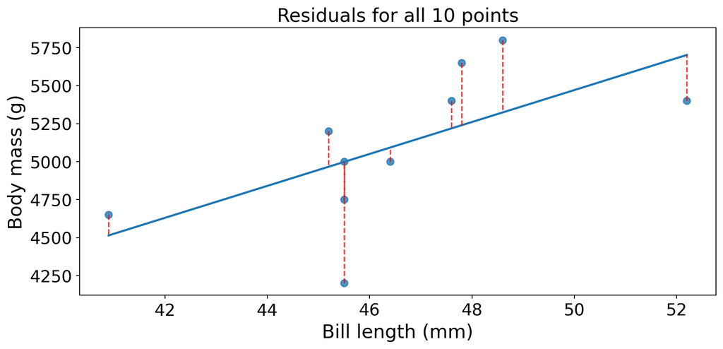

## Residuals vs Horizontal Mean Line

- Mean model uses one horizontal line
- Regression model tilts line with bill length
- Compare residual size for each model
- Smaller residual spread means better fit
- Regression usually beats mean-only baseline

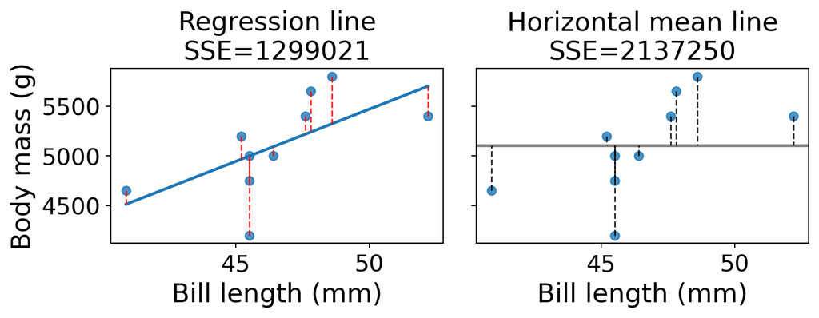

## Interpreting R Squared on the Sample

- R squared compares two error totals
- Baseline error comes from mean line
- Model error comes from regression line
- Higher R squared means more explained variance
- Here it is computed on the 10 penguins

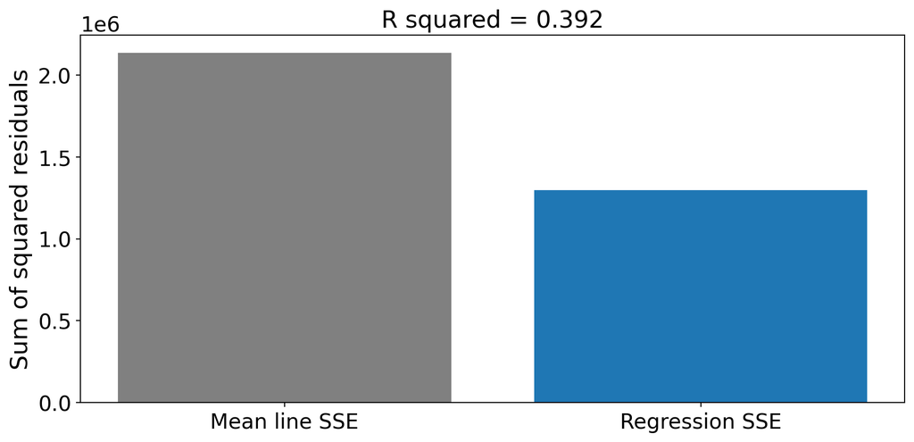

## F Statistic and P Value for the Slope

- Test if slope is different from zero
- F compares explained and unexplained variance
- Use sample size n and 2 parameters
- Small p value supports a real linear trend
- This is the same 10 Gentoo sample

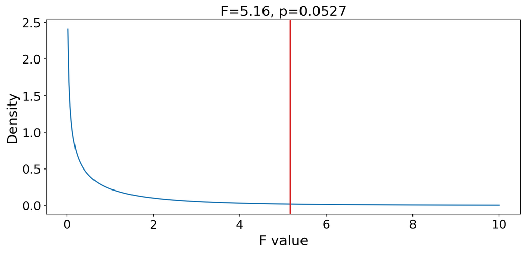

## Predictions Versus Observed Body Mass

- Predict body mass from bill length
- Compare predicted to observed values
- Perfect predictions sit on 45 degree line
- Distance from line is prediction error
- Pattern shows practical model quality

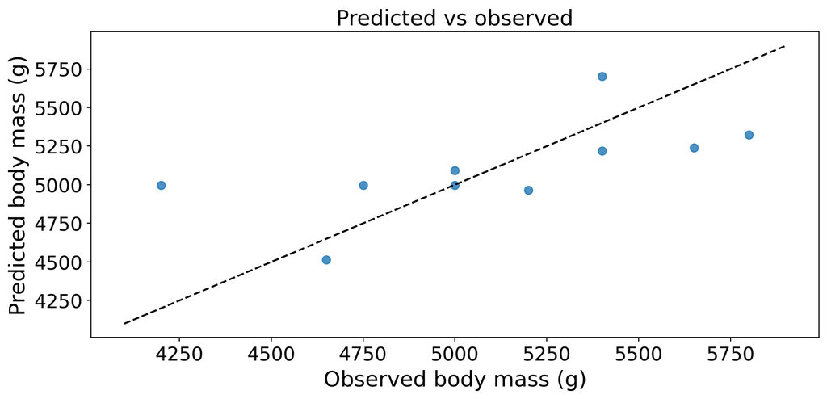

## Binary Predictor Regression with Sex

- Reuse the same 10 Gentoo penguins
- Encode sex as Female=0, Male=1
- Fit a linear regression with binary predictor
- Intercept is mean for Female group
- Slope is mean difference Male minus Female

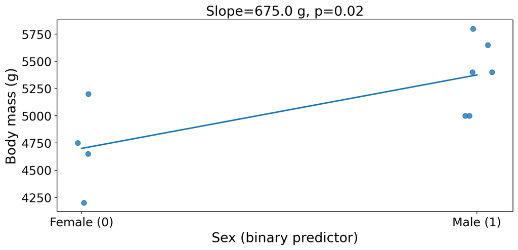

Multiple Regression Analysis (MRA)

## Dummy Coding for Species

- `species` is categorical, so we convert it into dummy variables
- `drop_first=True` uses one reference group automatically
- With penguins, reference is `Adelie` after sorting
- New columns become `species_Chinstrap` and `species_Gentoo`
- Each dummy compares that species to the reference group

```
   species_Chinstrap  species_Gentoo
0              False           False
1              False           False
2              False           False
4              False           False
5              False           False
```

[figure not shown]

## Linear Effects from the Full Model

- Full model uses all predictors in `model.mermaid`
- Outcome is `body_mass_g`; predictors are bill length, species, and sex
- Coefficients represent linear effects while holding others constant
- Effects whose intervals avoid zero are stronger evidence

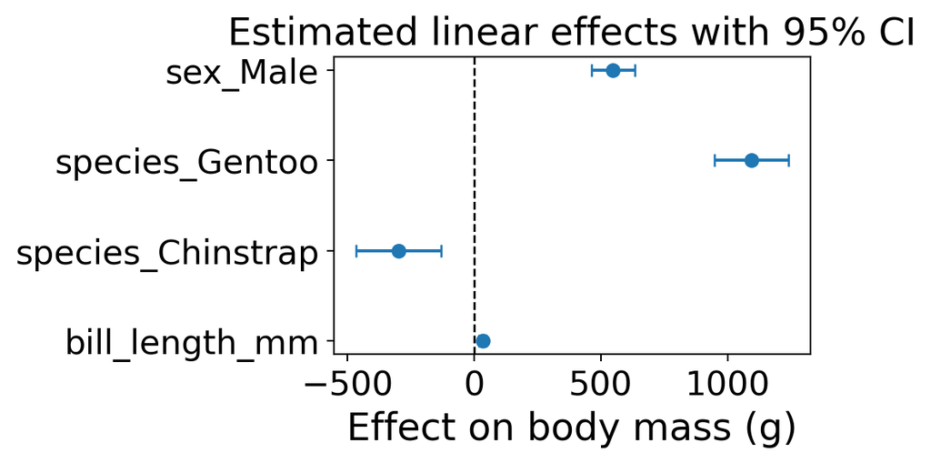

## Multiple Regression and Interpretation

- Fit one model with all predictors at the same time
- Use simple OLS matrix code with dummy-coded categorical variables
- For each coefficient, compute t statistic and p-value
- Report `R^2` to summarize overall variance explained
- Interpret each term relative to its reference category

```
                term    beta_g  p_value
0          Intercept  2169.270    0.000
1     bill_length_mm    32.537    0.000
2  species_Chinstrap  -298.766    0.001
3     species_Gentoo  1094.867    0.000
4           sex_Male   547.367    0.000

Interpretation:
- +1 mm bill length -> 32.5 g (p=1.15e-05)
- Chinstrap vs Adelie -> -298.8 g (p=0.000577)
- Gentoo vs Adelie -> 1094.9 g (p=0)
- Male vs Female -> 547.4 g (p=0)
- Model R^2 = 0.856
```

## Multicollinearity Check with VIF

- Multicollinearity means predictors carry overlapping information
- Variance inflation factor (VIF) measures this overlap per predictor
- Rule of thumb: VIF near 1 is low; above 5 can be concerning
- If VIF is high, simplify or re-express the predictor set

```
           predictor    VIF
0     bill_length_mm  5.585
1  species_Chinstrap  4.216
2     species_Gentoo  4.421
3           sex_Male  1.639
```

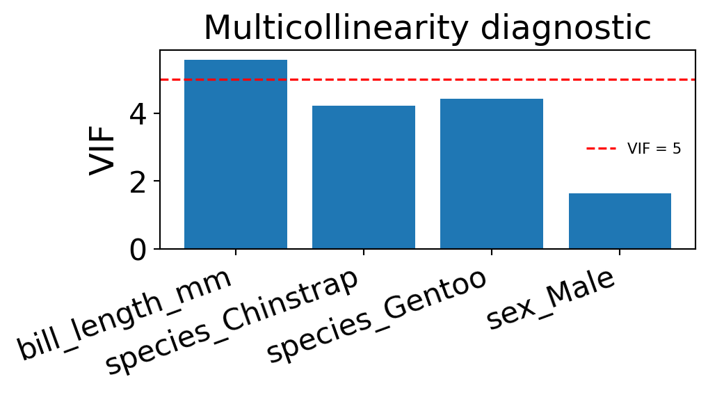

## Residual Q-Q Plot Diagnostic

- Q-Q plot checks whether residuals are close to normal
- Points near the line support the normal-error assumption
- Large tail deviations suggest skew or heavy tails
- This diagnostic complements p-values from regression outputs
- If assumptions fail, consider robust or transformed models

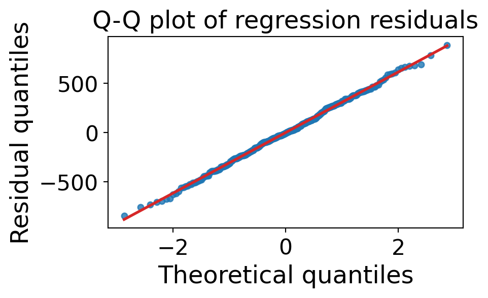

Factor Analysis

## COD Item Structure for Factor Analysis

- Use empirical COD variables 6 through 23 (1-based column positions)
- This subset captures core communication-attitude items in the COD instrument
- Complete-case rows are used for the factor-analysis item matrix
- Correlation heatmap reveals clusters and shared variance

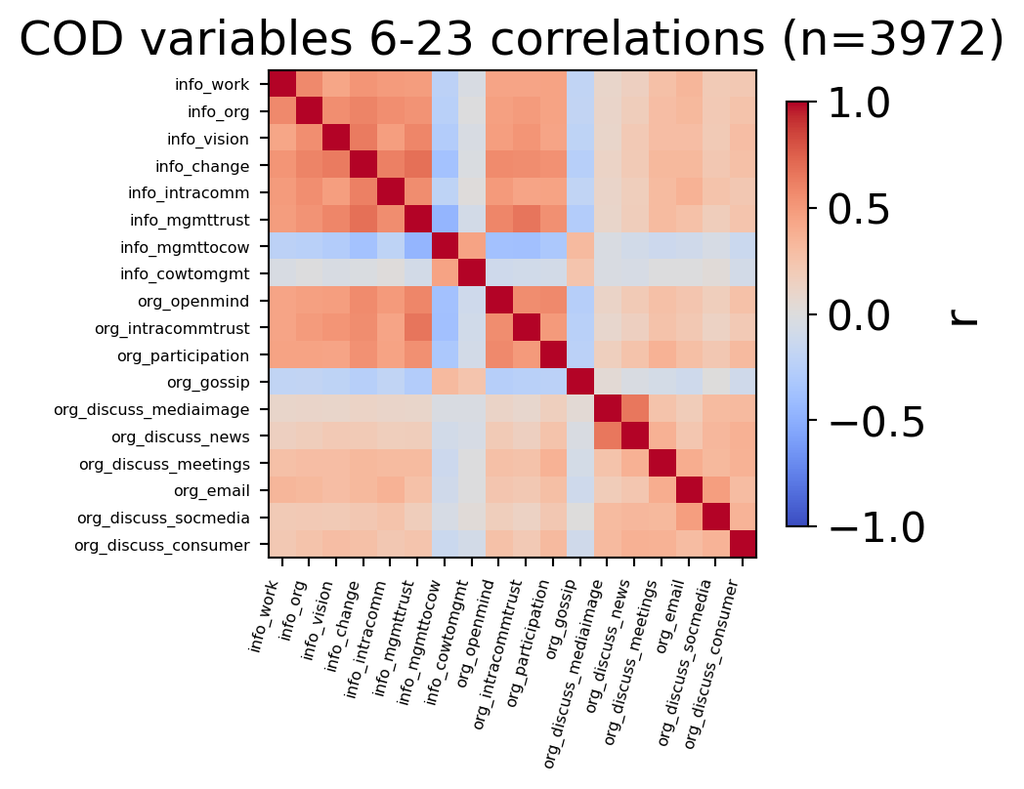

## Parallel Analysis to Select Factor Count

- Compute eigenvalues of the empirical item correlation matrix
- Simulate random data with same rows and columns
- Compare observed eigenvalues to random 95th-percentile eigenvalues
- Keep factors where observed eigenvalue exceeds random benchmark

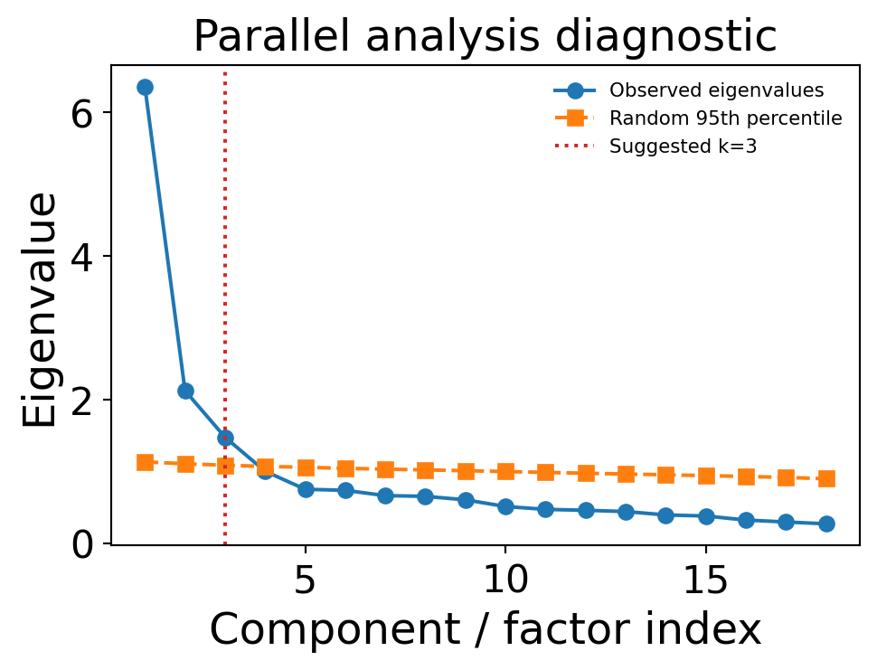

## Fit Diagnostics Across Candidate Solutions

- Fit 1 to 7 factor models using principal-axis factoring
- RMSR tracks residual correlation error (lower is better)
- Mean communality tracks shared variance captured by factors
- Diagnostics typically improve as factors increase
- Choose a solution balancing fit gain and interpretability

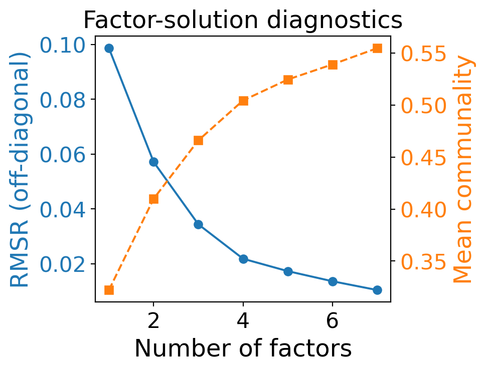

## Rotated Loadings and Added Factor Scores

- Fit the selected empirical solution (4 factors)
- Apply varimax rotation for cleaner loading interpretation
- Compute Bartlett factor scores for each complete-case row
- Add factor-score columns back into the COD dataset
- New factors can be used in later regression or clustering

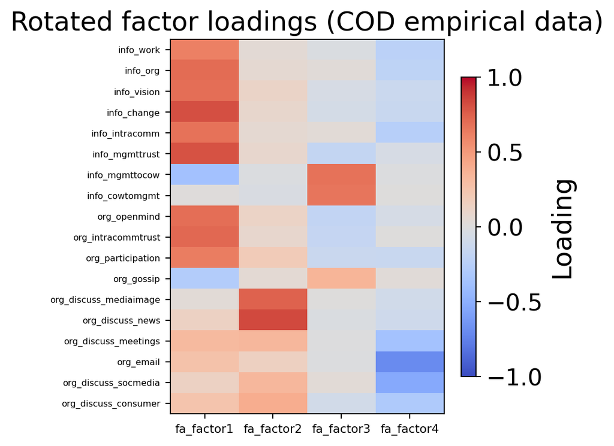

## Data analysis project

- Download sample [dataset](https://github.com/cca-cce/osm-comm/raw/refs/heads/main/csv/cod-260120.xlsx) and analyze model
- Perform descriptive statistics and data transformations
- Perform bivariate analyses and hypothesis testing
- `Perform multivariate analysis, multiple regression`

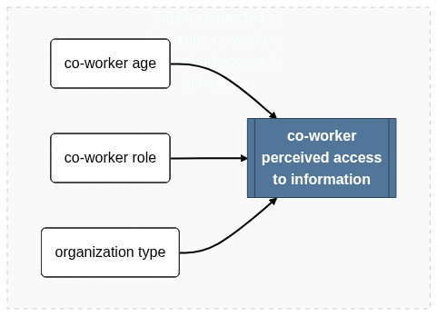

## Dependent variable: Information access

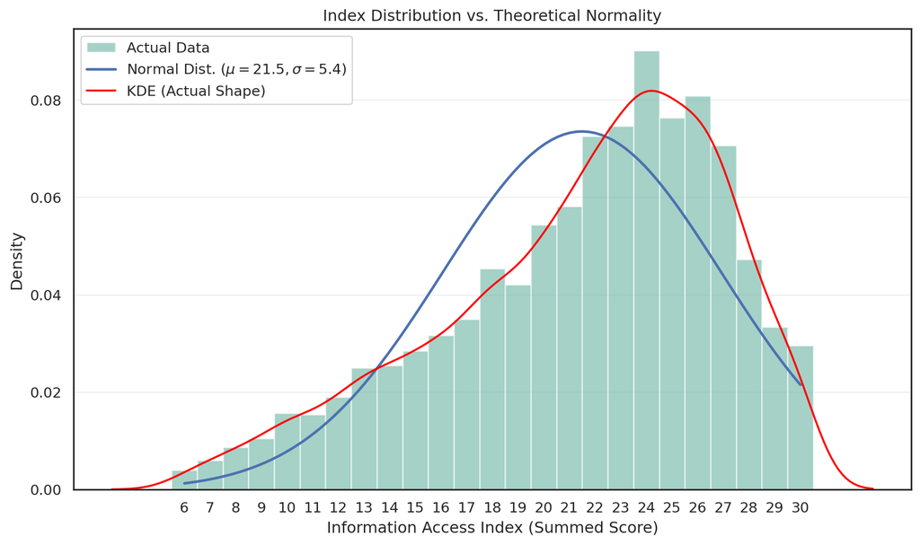

## Multivariate Regression Model

| Dep. Variable: | infoaccess_index | R-squared: | 0.028 |
| --- | --- | --- | --- |
| Model: | OLS | Adj. R-squared: | 0.027 |
| Method: | Least Squares | F-statistic: | 28.29 |
| Date: | Thu, 12 Feb 2026 | Prob (F-statistic): | 2.23e-28 |
| Time: | 07:41:13 | Log-Likelihood: | -14652 |
| No. Observations: | 4991 | AIC: | 29320 |
| Df Residuals: | 4985 | BIC: | 29360 |
| Df Model: | 5 | nan | nan |
| Covariance Type: | nonrobust | nan | nan |

|  | coef | std err | t | P> | t |  |
| --- | --- | --- | --- | --- | --- | --- |
| Intercept | 20.6894 | 0.323 | 64.064 | 0 | 20.056 | 21.322 |
| C(Org_type)[T.Public] | -0.0207 | 0.156 | -0.132 | 0.895 | -0.327 | 0.286 |
| age_years | 0.0253 | 0.006 | 4.085 | 0 | 0.013 | 0.037 |
| dummy_gender | 0.7658 | 0.144 | 5.328 | 0 | 0.484 | 1.048 |
| dummy_manager | 1.5114 | 0.158 | 9.559 | 0 | 1.201 | 1.821 |
| dummy_communicator | 0.0963 | 0.241 | 0.4 | 0.689 | -0.376 | 0.569 |

## Next steps

**Lecture lab 3, feb 11**

- Lecture notes: https://cca-cce.github.io/osm-comm/web/edu/skpm20-lecture-lab3.html
- Lab notebook: https://colab.research.google.com/github/cca-cce/osm-comm/blob/main/jnb/skpm20_labs.ipynb
- Sample assignment: https://colab.research.google.com/github/cca-cce/osm-comm/blob/main/jnb/skpm20_exam.ipynb

**References**

Field, Andy. 2022. “An Adventure in Statistics: The Reality Enigma.”

Poldrack, R. 2023. *Statistical Thinking: Analyzing Data in an Uncertain World*. Princeton University Press. https://statsthinking21.github.io/statsthinking21-core-site/.

Van de Ven, Andrew H. 2007. *Engaged Scholarship: A Guide for Organizational and Social Research*. Oxford University Press.